# SS3 to opal: North Pacific swordfish

Bridging the 2023 ISC two-sex, quarterly assessment to a single-sex, annual Stock Synthesis model, and from it to opal

Author

Nicholas Ducharme-Barth

Published

November 14, 2026

**Setup: read the caches**

```r
# Code is shown (folded) in the HTML version and hidden in the PDF.
knitr::opts_chunk$set(echo = knitr::is_html_output())
library(data.table)
library(ggplot2)
library(patchwork)

bridge = readRDS(file.path("data", "npo-swo-ss3-bridge-cache.rds"))
opal_c = readRDS(file.path("data", "npo-swo-opal-cache.rds"))
opal_s = readRDS(file.path("data", "npo-swo-opal-cache-sexavg.rds"))

theme_set(theme_bw(base_size = 11) +
          theme(legend.position = "bottom", panel.grid.minor = element_blank()))
fmt = function(x, d = 2) formatC(x, format = "f", digits = d, big.mark = ",")
sci = function(x, d = 1) formatC(x, format = "e", digits = d)
pct = function(x, d = 0) paste0(formatC(100 * x, format = "f", digits = d), "%")
# Pipe table with relative column widths (dash counts), for wide text tables
pipe_table = function(x, widths) {
    x = as.data.frame(x)
    row = function(v) paste0("| ", paste(gsub("\\|", "/", v), collapse = " | "), " |")
    cat(row(names(x)), paste0("|", paste0(":", strrep("-", widths), collapse = "|"), "|"),
        apply(x, 1, row), sep = "\n")
}

B = bridge$summary
S = opal_c$summary
Ss = opal_s$summary
b = function(s) B[step == s]
o = function(m) S[model == m]
os = function(m) Ss[model == m]
# One colour per model family in every figure, with line type as the
# second cue: SS3 black (the two-sex base case grey); O0 (opal at SS3's
# values) amber; fits with SS3's selectivity (O1 family) blue; opal's own
# selectivity (O2, O2b) red; quarterly opal (phase D) green. Within a family
# the diagnostic variants are dashed or dotted, and the final model, D, is
# drawn thicker. The bridge steps take a light-to-dark ramp in step order.
model_col = c(`SS3 base case` = "#8c8c8c", SS3 = "black", O0 = "#eda100",
              O1 = "#2a78d6", `O1-noLF` = "#2a78d6", `O1-noS6` = "#2a78d6",
              O2 = "#e34948", O2b = "#e34948",
              D0 = "#008300", `D0-even` = "#008300", D = "#008300")
model_lty = c(`SS3 base case` = "solid", SS3 = "solid", O0 = "solid",
              O1 = "solid", `O1-noLF` = "22", `O1-noS6` = "13",
              O2 = "22", O2b = "solid", D0 = "22", `D0-even` = "13", D = "solid")
model_lwd = setNames(ifelse(names(model_col) == "D", 1.3, 0.65), names(model_col))
scale_models = function(models = names(model_col)) {
    list(scale_colour_manual(values = model_col[models], breaks = models),
         scale_linetype_manual(values = model_lty[models], breaks = models),
         scale_linewidth_manual(values = model_lwd[models], breaks = models))
}
bridge_col = c(B0 = "black", setNames(colorRampPalette(c("#f0b27a", "#5c2a0a"))(5),
                                      paste0("B", c(1, 2, 3, 4, 6))))
variant_lab = c(female = "Female biology (B7)", sexavg = "Sex-averaged biology (B7s)")

# All spawning-biomass trajectories: the two-sex base case, SS3 B7 or B7s
# (as "SS3") and every opal model, by variant. Depletion is SSB / SSB0
# (SS3) or SSB / B0 (opal).
base_ts = bridge$timeseries[step == "00-base", .(model = "SS3 base case", year, ssb, depletion, recruits)]
ALL = rbindlist(lapply(c("female", "sexavg"), function(v) {
    tr = copy(if (v == "female") opal_c$trajectory else opal_s$trajectory)
    tr[grepl("^SS3", model), model := "SS3"]
    rbind(copy(base_ts)[, variant := v], tr[, variant := v], use.names = TRUE)
}))
ALL[, variant := factor(variant_lab[variant], levels = variant_lab)]
rel_ss3_v = function(v, m) {
    x = merge(ALL[variant == variant_lab[[v]] & model == m],
              ALL[variant == variant_lab[[v]] & model == "SS3", .(year, s = ssb)], by = "year")
    x[, ssb / s - 1]
}
```

```r
b0 = b("00-base"); b1 = b("01-single-sex"); b1s = b("01s-sex-averaged")
b2 = b("02-block-split"); b3 = b("03-spawn-month-1"); b4 = b("04-annual")
b5 = b("05-annual-comps"); b6 = b("06-settle-month-1"); b7 = b("07-index-month-1")
b3s = b("03s-spawn-month-1"); b4s = b("04s-annual"); b7s = b("07s-index-month-1")
tq = opal_c$timing_q[, .(end = rel[.N], max = max(abs(rel))), by = .(catch, weight)]
tq_s = opal_s$timing_q[, .(end = rel[.N], max = max(abs(rel))), by = .(catch, weight)]
rel_ss3 = function(cache, m) {
    tr = cache$trajectory
    ss = tr[grepl("^SS3", model)]
    x = merge(tr[model == m], ss[, .(year, s = ssb)], by = "year")
    x[, ssb / s - 1]
}
tm = opal_c$timing
tm_end = tm[, .(end = rel[.N], max = max(abs(rel))), by = .(removal, weight)]
br = opal_c$bridge
```

# Executive summary

```r
D_f = o("D"); D_s = os("D")
ss3_f = o("SS3 B7"); ss3_s = os("SS3 B7s")
```

This case study converts the 2023 ISC benchmark assessment of North Pacific swordfish (ISC Billfish Working Group 2023), a two-sex Stock Synthesis model with four seasons per year, into opal, a single-sex, RTMB-based age-structured model, and compares the two. opal itself is not changed. Where it cannot represent the SS3 model, the SS3 model is simplified in a bridge of SS3 models, or the difference is measured and documented. The model runs are preliminary explorations and are not advice on the stock.

- **The SS3 bridge** (Section 3) turns the base case into single-sex, annual SS3 models opal can represent. Selectivity blocks become fleets, and spawning and settlement move to the start of the year. Choosing one biology for two sexes is the largest change. With female growth and M (B7), terminal depletion (SSB<sub>2021</sub>/SSB<sub>0</sub>) is 0.292. With growth and M averaged over the sexes (B7s) it is 0.434, against 0.358 in the base case.
- **The conversion is exact** where opal and SS3 share structure (Section 4). Replaying SS3’s dynamics with its own catch equation and catch weights reproduces SS3’s spawning biomass to 4.0e-06.
- **At SS3’s parameter values (O0)** opal differs from SS3 by up to 28% in spawning biomass (Section 5). opal removes each year’s catch at the start of the year and builds its initial equilibrium the same way, whereas SS3 removes catch through the year.
- **The final opal model is D** (Section 8, Section 9.1). It uses opal’s own selectivity curves, with the parameters the data cannot determine fixed (O2b), and four seasons per year with the observed quarterly catch. It is the most complete converged opal configuration:
  - it estimates its own selectivity;
  - it converges with a positive-definite Hessian;
  - it fits the data better than O2b, the other converged model with opal’s own selectivity;
  - it removes the start-of-year catch timing.

  Its terminal depletion is 0.297 against SS3 B7’s 0.292 (sex-averaged: 0.462 against 0.434). It is not, however, the opal model that tracks SS3 most closely. Its early years are well above SS3’s (by 38% in 1975), and over the whole series O1, with SS3’s selectivity, stays closer. D also rests on approximations (mid-year weights in every quarter, some selectivity parameters fixed at bounds) listed in Section 9.1.
- **What opal would need** to model the base case directly (Section 10):
  - two sexes;
  - spawning and settlement within the year;
  - season-specific weight- and length-at-age (quarterly removals with one start-of-year weight vector collapse the stock);
  - time-varying selectivity;
  - an index of recruitment;
  - analytically solved catchability.

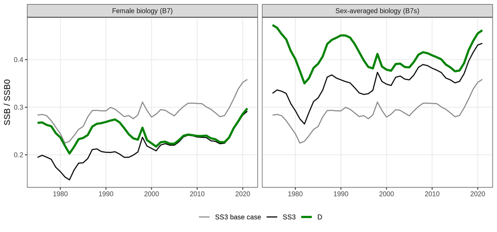

Figure 1: Spawning biomass relative to unfished: the two-sex SS3 base case (grey), the single-sex, annual SS3 model opal is converted from (black; B7 left, B7s right) and the final opal model, D (green).

```r
hd = ALL[model %in% c("SS3 base case", "SS3", "D")]
hd[, model := factor(model, levels = c("SS3 base case", "SS3", "D"))]
ggplot(hd, aes(year, depletion, colour = model, linetype = model, linewidth = model)) +
    geom_line() +
    facet_wrap(~variant) +
    scale_models(c("SS3 base case", "SS3", "D")) +
    labs(x = NULL, y = "SSB / SSB0", colour = NULL, linetype = NULL, linewidth = NULL)
```

# 1 Overview

The 2023 ISC benchmark assessment of North Pacific swordfish (*Xiphias gladius*) (ISC Billfish Working Group 2023) uses Stock Synthesis [SS3 3.30.20; Methot and Wetzel (2013)]. The model has two sexes, which differ in growth and natural mortality, and four seasons (quarters) per year with annual ages. Spawning is in the second quarter (month 5), recruits settle in month 7, and catch, indices and length compositions are entered by quarter. Two fleets have blocks of time-varying selectivity, and one index measures recruitment directly. opal has one sex. Its SS3 converter handles one season per year. Within a year, opal removes catch at the start of each season, and it has no recruitment index. The base case therefore cannot be converted directly.

This case study bridges in two stages:

1. **Within SS3** (Section 3), from the base case to a single-sex, annual SS3 model whose structure opal can represent. Each step makes one change, so its effect is measured on its own. Collapsing two sexes into one requires choosing one biology. The bridge is therefore built twice: with female growth and M (ending in B7) and with growth and M averaged over the sexes (ending in B7s).
2. **SS3 to opal** (Section 4), converting B7 with the shared converter in `shared/ss3-to-opal/`. The conversion is checked and SS3’s dynamics are replayed with opal’s catch timing (Section 5). opal is then fitted (Section 6). Section 7 repeats the conversion and fits for B7s, and Section 8 runs the opal models with four seasons per year (phase D). Section 9 traces the steps from SS3 to the final opal model, and Section 9.1 sets out how that model was chosen and its limitations.

Section 10 lists where opal falls short of SS3 or differs from it, and what opal would need to model the base case itself. The case study documents these differences; it does not change opal.

# 2 The 2023 assessment

## 2.1 Stock, fisheries and data

The stock area is the North Pacific north of the equator in the WCPFC Convention Area and north of 10°N in the IATTC Convention Area. The model has one area and models the western-central and eastern North Pacific with fleets as areas. It runs from 1975 to 2021 with four quarterly seasons per year. Ages are annual (0-15, plus group at 15), with 5 cm population length bins from 10 to 260 cm.

```r
fl = copy(opal_c$fleets)
knitr::kable(fl[, .(`opal fishery` = fishery, `SS3 fleet` = ss3_fleet, Name = name,
                    Units = units, Compositions = ifelse(lf, "yes", ""))],
             format = "pipe")
```

Table 1: Fleets of the base case and of B7 as opal fisheries. Units: catch (or index) in tonnes (1) or numbers (2). Compositions: fitted length compositions (lambda 0.5 in SS3).

| opal fishery | SS3 fleet | Name | Units | Compositions |
| --- | --- | --- | --- | --- |
| 1 | 1 | F1_JPN_WCNPO_OSDWCOLL_late_Area1 | 2 | yes |
| 2 | 2 | F2_TWN_WCNPO_DWLL_late | 1 | yes |
| 3 | 3 | F3_US_WCNPO_LL_shallow_late | 2 | yes |
| 4 | 4 | F4_IATTC | 1 | yes |
| 5 | 5 | F5_JPN_EPO_OSDWLL | 2 |  |
| 6 | 6 | F6_JPN_WCNPO_OSDWLL_early_Area1 | 2 | yes |
| 7 | 7 | F7_JPN_WCNPO_CODF | 1 | yes |
| 8 | 8 | F8_US_WCNPO_LL_shallow_early | 2 | yes |
| 9 | 9 | F9_US_WCNPO_LL_deep | 2 |  |
| 10 | 10 | F10_JPN_WCNPO_OSDF | 1 |  |
| 11 | 11 | F11_JPN_WCNPO_Other_early | 1 |  |
| 12 | 12 | F12_JPN_WCNPO_Other_late | 1 |  |
| 13 | 13 | F13_TWN_WCNPO_DWLL_early | 1 |  |
| 14 | 14 | F14_TWN_WCNPO_Other | 1 |  |
| 15 | 15 | F15_US_WCNPO_GN | 1 |  |
| 16 | 16 | F16_US_WCNPO_Other | 1 |  |
| 17 | 17 | F17_JPN_WCNPO_OSDWLL_early_Area2 | 2 |  |
| 18 | 18 | F18_JPN_WCNPO_OSDWLL_late_Area2 | 2 |  |
| 19 | 19 | F19_WCPFC | 1 |  |
| 20 | 28 | F1_JPN_WCNPO_OSDWCOLL_late_Area1_1994_97 | 2 | yes |
| 21 | 29 | F12_JPN_WCNPO_Other_late_1994_97 | 1 |  |
| 22 | 31 | F2_TWN_WCNPO_DWLL_late_2004_09 | 1 | yes |
| 23 | 32 | F15_US_WCNPO_GN_2004_09 | 1 |  |
| 24 | 33 | F16_US_WCNPO_Other_2004_09 | 1 |  |
| 25 | 34 | F19_WCPFC_2004_09 | 1 |  |
| 26 | 20 | S1_JPN_WCNPO_OSDWLL_early_Area1 | 2 |  |
| 27 | 21 | S2_JPN_WCNPO_OSDWCOLL_late_Area1 | 2 |  |
| 28 | 22 | S3_JPN_WCNPO_OSDWLL_early_Area2 | 2 |  |
| 29 | 23 | S4_JPN_WCNPO_OSDWLL_late_Area2 | 2 |  |
| 30 | 25 | S6_US_WCNPO_LL_deep | 2 |  |
| 31 | 26 | S7_US_WCNPO_LL_shallow_early | 2 |  |
| 32 | 30 | S2_JPN_WCNPO_OSDWCOLL_late_Area1_1994_97 | 2 |  |

The base case has 19 fishing fleets. Japanese and US longline catches are in thousands of fish and all others in tonnes. It has eight abundance indices, of which S5 (Chinese Taipei longline) and S8 (US shallow-set longline, late period) have lambda 0. S6, the US deep-set longline index, is a **recruitment index**: SS3 compares it with the year’s age-0 recruitment (units code 33), so its selectivity plays no part. Length compositions (sex-combined) are entered by quarter for nine fleets. Eight have lambda 0.5 (F1-F4 and F6-F9), but every F9 observation is excluded (negative year), so seven fleets’ compositions are fitted. F5’s have lambda 0.

## 2.2 Biology and structure

```r
knitr::kable(data.table(
    Item = c("SS3 version", "Sexes", "Seasons", "Ages", "Growth", "Natural mortality",
             "Maturity and fecundity", "Spawning and settlement",
             "Stock-recruitment", "Recruitment deviations", "Fishing mortality",
             "Selectivity", "Initial equilibrium", "Catchability", "Data weighting"),
    `Base case` = c(
        "3.30.20.00",
        "2; sex ratio at birth 1:1; SSB is female spawning biomass",
        "4 quarters, 2 subseasons",
        "0-15 (annual)",
        "von Bertalanffy, L1 at age 0.5, L2 at age 15; females 80.1 / 226.3 cm, K 0.246; males 83.4 / 206.4 cm, K 0.271; CV 0.1 (fixed)",
        "age-specific, fixed; females 0.42 at age 0 to 0.22 from age 4; males 0.40 to 0.36",
        "length logistic (L50 143.7 cm); fecundity = weight",
        "spawning month 5 (quarter 2); settlement month 7 at age 0",
        "Beverton-Holt, h = 0.9, sigma_R = 0.42 (fixed)",
        "early 1965-1984, main 1985-2021, bias ramp",
        "hybrid (F method 3); F-ballpark off",
        "length-based double normal (F1, F3, F6, F7, F8) or logistic (F2, F4); other fleets mirror; blocks on F1 (1994-97) and F2 (2004-09)",
        "initial F for F6 (initial-catch lambda 0)",
        "floated q for every index",
        "length compositions lambda 0.5; lambda 0 for the indices S5 and S8 and for F5's compositions")),
    format = "pipe")
```

Table 2: Structure of the base case, from the model files.

| Item | Base case |
| --- | --- |
| SS3 version | 3.30.20.00 |
| Sexes | 2; sex ratio at birth 1:1; SSB is female spawning biomass |
| Seasons | 4 quarters, 2 subseasons |
| Ages | 0-15 (annual) |
| Growth | von Bertalanffy, L1 at age 0.5, L2 at age 15; females 80.1 / 226.3 cm, K 0.246; males 83.4 / 206.4 cm, K 0.271; CV 0.1 (fixed) |
| Natural mortality | age-specific, fixed; females 0.42 at age 0 to 0.22 from age 4; males 0.40 to 0.36 |
| Maturity and fecundity | length logistic (L50 143.7 cm); fecundity = weight |
| Spawning and settlement | spawning month 5 (quarter 2); settlement month 7 at age 0 |
| Stock-recruitment | Beverton-Holt, h = 0.9, sigma_R = 0.42 (fixed) |
| Recruitment deviations | early 1965-1984, main 1985-2021, bias ramp |
| Fishing mortality | hybrid (F method 3); F-ballpark off |
| Selectivity | length-based double normal (F1, F3, F6, F7, F8) or logistic (F2, F4); other fleets mirror; blocks on F1 (1994-97) and F2 (2004-09) |
| Initial equilibrium | initial F for F6 (initial-catch lambda 0) |
| Catchability | floated q for every index |
| Data weighting | length compositions lambda 0.5; lambda 0 for the indices S5 and S8 and for F5’s compositions |

The sexes share selectivity (no sex offsets), weight-length and maturity, and the compositions are sex-combined. The two sexes therefore differ only in growth and M. Males are smaller (L2 206.4 against 226.3 cm). From age 4, males have M of 0.36, against 0.22 for females. The report notes that the lack of sex-specific size data is one of the two main sources of uncertainty in the assessment. Section 2.6 of the report describes the model as single sex, but the model files have two sexes.

# 3 The SS3 bridge

`scripts/01-build-ss3-bridge.r` builds each step and estimates it with SS3 3.30.22.1, Hessian included. Each step makes one change:

- **B0**: as supplied, re-run with 3.30.22.1 from the supplied par file.
- **B1**: single sex (`Nsexes = -1`, so spawning biomass is that of the single sex times the female fraction 0.5). Female growth, M and weight-length are used, and the sex-combined compositions keep one copy of their vector.
- **B1s** (built from B0): as B1, with sex-averaged biology. M at age is the rate that takes the unfished numbers of both sexes from one age to the next. L1, L2 and K are fitted to the mean length-at-age of the two sexes, weighted by their unfished numbers. For the plus group, the two sexes’ M are weighted by their unfished numbers at age 15, a slight overestimate of the plus group’s M (its sex ratio shifts further towards females at older ages).
- **B2**: the selectivity blocks become fleets, together with every fleet that mirrors a blocked fleet. The 1994-97 fleets are F1, F12 and the index S2 (fleets 28-30). The 2004-09 fleets are F2, F15, F16 and F19 (fleets 31-34). F13 and F14 mirror F2 and F1 but have no catch in the block years. S5 has lambda 0 and is not split.
- **B3**: spawning in month 1 (season 1) instead of month 5.
- **B4**: one season, with the catches summed over the quarters.
- **B5**: one length composition per fleet and year, combining the quarters (sample sizes summed, proportions weighted by sample size).
- **B6**: recruits settle in month 1 at age 0 instead of month 7.
- **B7**: indices observed in month 1.
- **B2s-B7s**: the same six steps built from B1s (sex-averaged biology).

```r
stopifnot(all(B$hessian_ok))
knitr::kable(B[, .(Step = label, `Est. par.` = n_par, NLL = fmt(nll, 2),
                   `Max. grad.` = sci(max_gradient), SSB0 = fmt(ssb0, 0),
                   SSB2021 = fmt(ssb_2021, 0), `SSB2021/SSB0` = fmt(depletion, 3),
                   F2021 = fmt(f_2021, 3), `SSB MSY` = fmt(ssb_msy, 0))],
             format = "pipe", align = "lrrrrrrrr")
```

Table 3: The SS3 bridge. NLL is SS3’s total; B5 changes its constant (see text). F2021 is the average F over ages 1-10. All steps converged (maximum gradient below 2e-3) with a positive-definite Hessian.

| Step | Est. par. | NLL | Max. grad. | SSB0 | SSB2021 | SSB2021/SSB0 | F2021 | SSB MSY |
| --- | --- | --- | --- | --- | --- | --- | --- | --- |
| B0 base case | 86 | 289.30 | 5.8e-05 | 99,808 | 35,778 | 0.358 | 0.087 | 16,388 |
| B1 single sex | 86 | 293.40 | 2.4e-05 | 78,149 | 20,197 | 0.258 | 0.118 | 14,996 |
| B2 blocks as fleets | 86 | 292.65 | 5.2e-06 | 78,558 | 20,308 | 0.259 | 0.118 | 15,103 |
| B3 spawning month 1 | 86 | 292.59 | 2.0e-05 | 83,206 | 23,245 | 0.279 | 0.118 | 16,975 |
| B4 annual | 86 | 291.69 | 1.6e-05 | 82,574 | 22,717 | 0.275 | 0.120 | 16,507 |
| B5 annual compositions | 86 | 42.79 | 1.9e-03 | 82,574 | 22,717 | 0.275 | 0.120 | 16,507 |
| B6 settlement month 1 | 86 | 36.49 | 4.6e-05 | 81,740 | 23,833 | 0.292 | 0.134 | 15,949 |
| B7 index month 1 | 86 | 36.49 | 4.6e-05 | 81,740 | 23,833 | 0.292 | 0.134 | 15,949 |
| B1s sex-averaged biology | 86 | 292.09 | 9.7e-05 | 66,937 | 26,008 | 0.389 | 0.089 | 11,818 |
| B2s blocks as fleets | 86 | 291.44 | 8.5e-05 | 66,752 | 25,976 | 0.389 | 0.089 | 11,802 |
| B3s spawning month 1 | 86 | 291.42 | 1.1e-05 | 72,440 | 29,971 | 0.414 | 0.089 | 13,650 |
| B4s annual | 86 | 295.92 | 8.2e-05 | 71,579 | 29,234 | 0.408 | 0.091 | 13,164 |
| B5s annual compositions | 86 | 47.01 | 9.0e-05 | 71,579 | 29,234 | 0.408 | 0.091 | 13,164 |
| B6s settlement month 1 | 86 | 25.78 | 5.1e-05 | 73,043 | 31,717 | 0.434 | 0.099 | 13,166 |
| B7s index month 1 | 86 | 25.78 | 5.1e-05 | 73,043 | 31,717 | 0.434 | 0.099 | 13,166 |

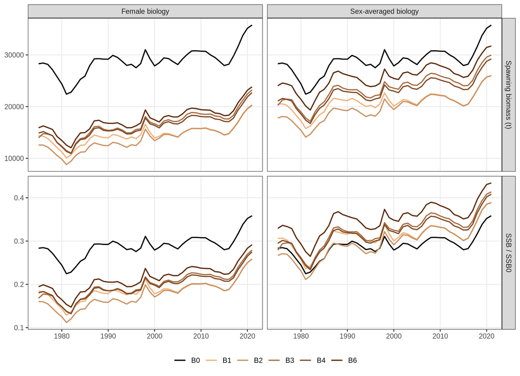

Figure 2: Female spawning biomass (top) and depletion (bottom) along the SS3 bridge: the female chain (left, with the base case B0) and the sex-averaged chain (right). B5 and B7 coincide with B4 and B6.

```r
ts = copy(bridge$timeseries)[!grepl("^0[57]", step)]
ts[, chain := ifelse(grepl("^0[1-7]s", step), "Sex-averaged biology", "Female biology")]
ts[step == "00-base", chain := "Female biology"]
ts[, stage := sub("s? .*", "", label)]
ts[stage == "B1s", stage := "B1"]
ts = rbind(ts, copy(ts[step == "00-base"])[, chain := "Sex-averaged biology"])
long = melt(ts[, .(chain, stage, year, `Spawning biomass (t)` = ssb, `SSB / SSB0` = depletion)],
            id.vars = c("chain", "stage", "year"))
ggplot(long, aes(year, value, colour = stage)) +
    geom_line(linewidth = 0.7) +
    facet_grid(variable ~ chain, scales = "free_y") +
    scale_colour_manual(values = bridge_col) +
    labs(x = NULL, y = NULL, colour = NULL) +
    guides(colour = guide_legend(nrow = 1))
```

**Single sex (B1).** This step changes the stock most. The compositions are sex-combined, so no data are lost and the length NLL changes little (481.3 to 486.0). The population dynamics change, however. Applied to every fish, the female M of 0.22 from age 4 gives males a much longer life than their own M of 0.36. Female growth also makes the males larger. SSB<sub>0</sub> falls from 99,808 t to 78,149 t and terminal depletion from 0.358 to 0.258. The initial F of F6 rises from 0.99 to 1.39, so the 1975 stock starts further down. B1s, with M and growth averaged over the sexes, gives SSB<sub>0</sub> 66,937 t, depletion 0.389 and initial F 1.00. Its NLL (292.09) is lower than B1’s. The difference between B1 and B1s is the cost of choosing one sex’s biology for both. In B1s, F4’s logistic inflection lies within SS3’s status margin of its upper bound of 150 cm (148.8 cm; the base case’s is 148.3 cm).

**Blocks as fleets (B2).** At B1’s estimates B2 reproduces B1’s likelihood components exactly (checked by evaluating B2 at B1’s parameters). The only change is S2’s catchability: S2 in 1994-97 is an index of its own with its own floated q. SS3’s q mirror (link type 2) would share S2’s q. That version reproduces B1 at B1’s estimates, but the gradient of the shared q is wrong there (4.3 at B1’s optimum), and the minimiser stops short with gradients of 5-60. With its own q, B2 converges at NLL 292.653 (B1: 293.399). The stock barely moves (depletion 0.259).

**Timing and seasons (B3-B7).** SS3 does not allow spawning after the start of the season in which recruits settle. A one-season model with settlement in month 7 therefore needs spawning at the start of the year, which B3 introduces while the model is still quarterly. Spawning in month 1 rather than 5 removes four months of mortality before spawning. SSB<sub>0</sub> rises to 83,206 t and depletion to 0.279. Merging the quarters (B4) changes the timing of the catch, which is now removed through the year rather than quarter by quarter. It also changes the fishery compositions’ expected lengths, which become catch-weighted over the year. Depletion moves to 0.275. The estimated initial F falls from 1.59 to 0.34, yet the 1975 stock is about as depleted (0.168 and 0.180). The quarterly and annual initial equilibria apply F6’s selectivity differently, so the two values are not comparable. Combining the quarterly compositions (B5) leaves every estimate unchanged. Within a year they share one expected composition, so the multinomial kernel is unchanged. SS3’s NLL falls from 291.7 to 42.8 only because its composition likelihood includes the observed proportions’ own entropy, which differs between quarterly and annual vectors. Settlement at the start of the year (B6) makes age-0 fish a full year old at the end of the year, as in opal. Depletion moves to 0.292 and F<sub>MSY</sub> from 0.180 to 0.224. Observing the indices in month 1 (B7) changes nothing for the fitted indices. With two subseasons, SS3 places observations in months 1-6 at the same time, and the indices moved are observed in months 1 or 4 (S6, a recruitment index, does not depend on timing). Only S5, with lambda 0, moves from month 7.

**The sex-averaged chain (B2s-B7s).** The same steps built from B1s change the stock in the same direction. Blocks as fleets leave it unchanged (depletion 0.389), spawning in month 1 raises it to 0.414, and B7s ends at 0.434 (B7: 0.292). One difference is that merging the quarters costs fit in this chain. The NLL rises from 291.42 to 295.92, against a fall from 292.59 to 291.69 in the female chain. In both chains, twelve starts (initial F 0.1-1.0, ln(R<sub>0</sub>) raised by 0-0.6) all converge to the committed B4 or B4s minimum. In the sex-averaged chain F4’s logistic inflection lies within SS3’s status margin of its 150 cm upper bound, as it nearly does in the base case (148.3 cm).

# 4 Converting B7 to opal

`scripts/02-convert-fit-npo-swo-opal.r` converts B7 with `config/npo-swo-b7.yaml`. opal has 47 annual time steps of one season and ages 0-15. Recruits enter at age 0 at the start of the year from that year’s spawning biomass, as in B7. The 25 fishing fleets become opal fisheries 1-25 in SS3 order, and the seven indices with lambda 1 become fisheries 26-32. The biology (weight, maturity, spawning output and M at age) is SS3’s start-of-year endgrowth table. Spawning output is mature female biomass times the female fraction 0.5. Sections 4-6 describe B7; B7s is converted and fitted in the same way (Section 7).

## 4.1 Reconciliation

```r
rc = copy(opal_c$recon)
catch_rows = grepl("^catch total", rc$quantity)
rc_tab = rbind(
    data.table(quantity = sprintf("catch totals, %d fleets", sum(catch_rows)),
               rel_diff = max(abs(rc$rel_diff[catch_rows])), pass = all(rc$pass[catch_rows])),
    rc[!catch_rows & !is.na(pass), .(quantity, rel_diff = abs(rel_diff), pass)])
knitr::kable(rc_tab[, .(Quantity = quantity, `Max. rel. diff.` = sci(rel_diff), Pass = pass)],
             format = "pipe")
```

Table 4: Reconciliation with SS3 (exact comparisons). The 25 catch totals are summarised in one row.

| Quantity | Max. rel. diff. | Pass |
| --- | --- | --- |
| catch totals, 25 fleets | 0.0e+00 | TRUE |
| CPUE observation count (kept SS3 index fleets) | 0.0e+00 | TRUE |
| LF total input sample size | 0.0e+00 | TRUE |
| LF observation rows | 0.0e+00 | TRUE |
| unfished spawning potential per recruit | 5.9e-07 | TRUE |
| total weight summed over ages (Wt_Beg) | 0.0e+00 | TRUE |

## 4.2 Growth and length-at-age

opal’s growth curve does not enter the biology on this route. It only maps length-based selectivity to age and predicts the length compositions through opal’s probability of length at age. SS3 builds a fishery’s selectivity-at-age and its expected compositions from mid-year lengths, because the fishery’s catch is taken through the year. opal’s growth is therefore fitted to SS3’s mid-year length-at-age. The start-of-year lengths cannot be fitted in any case. SS3 grows age-0 fish linearly from 10 cm at settlement to L1 at age 0.5. A Schnute curve through them misses by up to 42 cm (RMSE 11.7 cm). At mid-year, the RMSE is 0.45 cm (Figure 3).

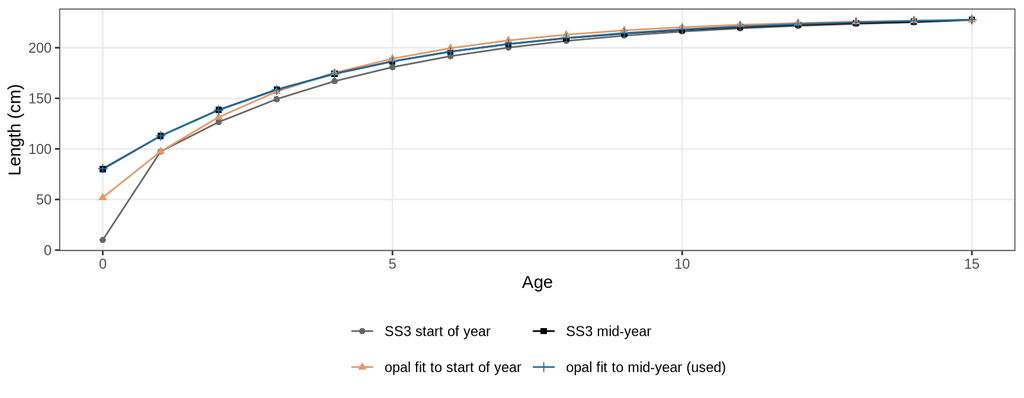

Figure 3: Length-at-age: SS3 B7 at the start of the year and at mid-year, opal’s Schnute curve fitted to each (the mid-year fit is used).

```r
laa = melt(opal_c$laa, id.vars = "age")
laa[, variable := factor(variable, levels = c("ss3_beg", "opal_beg_fit", "ss3_mid", "opal"),
                         labels = c("SS3 start of year", "opal fit to start of year",
                                    "SS3 mid-year", "opal fit to mid-year (used)"))]
ggplot(laa, aes(age, value, colour = variable, shape = variable)) +
    geom_line() + geom_point() +
    scale_colour_manual(values = c("grey40", "#E59866", "black", "#2471A3")) +
    labs(x = "Age", y = "Length (cm)", colour = NULL, shape = NULL) +
    guides(colour = guide_legend(nrow = 2))
```

## 4.3 Selectivity and the recruitment index

opal’s double normal and logistic curves reproduce SS3’s selectivity-at-length for every fishery to within 1.5e-05. The fleets that mirror another take their source fleet’s parameters. Mapped to age through opal’s growth, the starting selectivity-at-age is within 0.018 of SS3’s for every fishery.

S6 has no opal equivalent. opal predicts an index from numbers- or biomass-at-age times a selectivity. S6 is therefore converted as an index in numbers whose selectivity is 1 at age 0 and 0 at older ages. Its observation at the start of year *y* then predicts that year’s age-0 recruits, as SS3’s does. In O0 and O1 this is a row of SS3’s selectivity-at-age. `sel_fa_external` replaces the selectivity of every fishery, so in O2 (opal’s own curves) S6 is an age-based (`sel_basis_f = 2`) double normal. Its peak is at age -1, so the plateau, which is at least one age wide, ends at age 0, and both limbs are steep. It gives selectivity 1 at age 0 and below 1e-4 at older ages, and is fixed. The converter reads SS3’s units code 33 as biomass and S6’s size pattern 0 as selectivity 1 at every age. The script overrides both.

# 5 opal at SS3’s values

O0 is opal at B7’s parameter values with SS3’s selectivity-at-age, and nothing estimated.

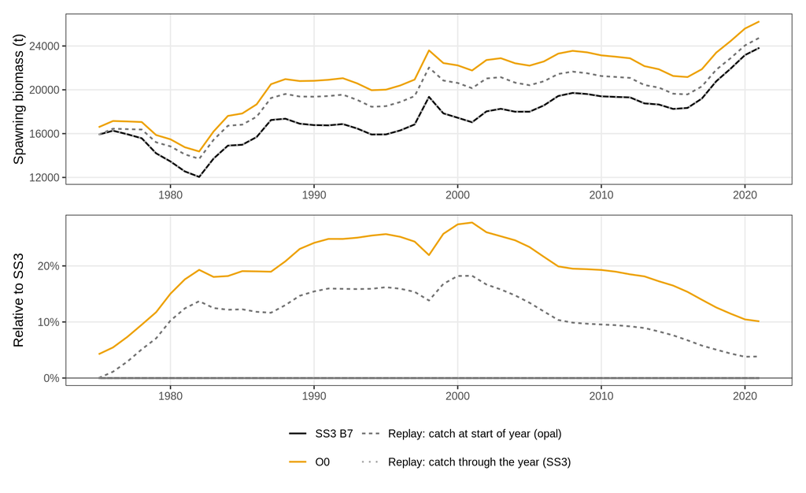

Figure 4: O0 against SS3 B7: spawning biomass (top) and relative difference (bottom). The replays start from SS3’s 1975 numbers-at-age with SS3’s recruitment each year and differ only in how the catch is removed; the replay with SS3’s catch equation and catch weights lies on SS3.

```r
o0_series = c("SS3 B7", "O0", "Replay: catch at start of year (opal)",
           "Replay: catch through the year (SS3)")
d = rbind(data.table(year = 1975:2021, series = o0_series[1], ssb = br$ss3, rel = 0),
          data.table(year = 1975:2021, series = o0_series[2], ssb = br$opal, rel = br$rel_opal),
          tm[removal == "start of year (opal)" & weight == "start of year (opal)",
             .(year, series = o0_series[3], ssb, rel)],
          tm[grepl("Baranov", removal) & weight == "SS3 fleet catch weight",
             .(year, series = o0_series[4], ssb, rel)])
d[, series := factor(series, levels = o0_series)]
o0_col = setNames(c("black", model_col[["O0"]], "grey45", "grey65"), o0_series)
o0_lty = setNames(c("solid", "solid", "22", "13"), o0_series)
p1 = ggplot(d, aes(year, ssb, colour = series, linetype = series)) + geom_line(linewidth = 0.65) +
    labs(x = NULL, y = "Spawning biomass (t)", colour = NULL, linetype = NULL)
p2 = ggplot(d, aes(year, rel, colour = series, linetype = series)) + geom_line(linewidth = 0.65) +
    geom_hline(yintercept = 0, colour = "grey50") +
    scale_y_continuous(labels = scales::percent) +
    labs(x = NULL, y = "Relative to SS3", colour = NULL, linetype = NULL)
(p1 / p2) + plot_layout(guides = "collect") &
    scale_colour_manual(values = o0_col) & scale_linetype_manual(values = o0_lty) &
    theme(legend.position = "bottom") & guides(colour = guide_legend(ncol = 2))
```

Two things separate O0 from SS3.

**The initial equilibrium.** SS3 solves the 1975 equilibrium with F6’s initial F applied through the year. opal removes the equilibrium catch at the start of the year. opal’s 1975 numbers-at-age are 0.6% above SS3’s at age 0, rising to 19% in the plus group, and its 1975 spawning biomass is 4.2% above SS3’s.

**Catch timing and catch weight.** Table 5 replays SS3’s dynamics (SS3’s 1975 numbers and SS3’s recruits) with each year’s catch removed in different ways. Removing it through the year (Baranov, as SS3’s hybrid F), with each fleet’s SS3 catch weight-at-age, reproduces SS3 to 4.0e-06. This confirms that the converted catch, selectivity, M, spawning output and units are SS3’s. Removing the catch at the start of the year, as opal does, leaves spawning biomass up to 18% above SS3’s. The start-of-year weights opal uses partly offset this. With SS3’s (larger) catch weights, a start-of-year removal takes fewer fish of the weight-based fleets, and the difference grows to 38%. A mid-year (Pope) removal is within 5%.

```r
knitr::kable(tm_end[, .(Removal = removal, `Catch weight` = weight,
                        `2021` = pct(end, 1), `Max.` = pct(max, 1))], format = "pipe")
```

Table 5: SS3’s dynamics replayed with different catch removals: spawning biomass relative to SS3 B7 in 2021 and the largest absolute difference over 1975-2021.

| Removal | Catch weight | 2021 | Max. |
| --- | --- | --- | --- |
| start of year (opal) | start of year (opal) | 3.8% | 18.2% |
| start of year (opal) | SS3 fleet catch weight | 25.7% | 38.5% |
| mid-year (Pope) | SS3 fleet catch weight | -2.1% | 4.9% |
| through the year (Baranov, SS3) | mid-year | -4.9% | 5.3% |
| through the year (Baranov, SS3) | SS3 fleet catch weight | 0.0% | 0.0% |

# 6 opal fits

Growth, steepness (0.9), sigma<sub>R</sub> (0.42), M and the biology stay at SS3’s values, as in SS3. opal’s default priors are switched off (SS3’s prior lambda is 0) and the length compositions carry SS3’s lambda of 0.5. Every fit estimates B<sub>0</sub>, the recruitment deviations for 1976-2021, the initial-age deviations of the cohorts born 1965-1975, F6’s initial F and the seven catchabilities. SS3 floats q, and opal estimates it.

- **O1**: SS3’s selectivity-at-age, fixed.
- **O2**: opal’s selectivity curves, started at SS3’s. The parameters SS3 estimates are estimated (26, with the mirrors sharing their source fleet’s).
- **O2b**: O2 refitted with the selectivity parameters it cannot determine fixed at their O2 values (Table 7). Which parameters are fixed is decided from each fit (on a bound, or dominating a flat direction of the Hessian), so the fixed sets differ between the variants and in phase D. Comparisons of O2b and D across variants are therefore not exactly like-for-like.
- **O1-noLF**: O1 without the length compositions.
- **O1-noS6**: O1 without the recruitment index (the report’s sensitivity 15).

```r
knitr::kable(S[, .(Model = model, `Est. par.` = n_par,
                   Objective = ifelse(is.na(objective), "", fmt(objective, 2)),
                   `Max. grad.` = ifelse(is.na(max_gradient), "", sci(max_gradient)),
                   `PD Hessian` = ifelse(is.na(positive_hessian), "", positive_hessian),
                   B0 = fmt(B0, 0), `Init. F (F6)` = fmt(init_F6, 3),
                   SSB2021 = fmt(ssb_2021, 0), `SSB2021/B0` = fmt(depletion_2021, 3))],
             format = "pipe", align = "lrrrcrrrr")
```

Table 6: Fits. The objective values are opal’s and are not comparable with SS3’s likelihood (different constants).

| Model | Est. par. | Objective | Max. grad. | PD Hessian | B0 | Init. F (F6) | SSB2021 | SSB2021/B0 |
| --- | --- | --- | --- | --- | --- | --- | --- | --- |
| SS3 B7 | 86 |  |  |  | 81,740 | 0.326 | 23,833 | 0.292 |
| O0 | 0 | 5,747.70 |  |  | 81,740 | 0.326 | 26,243 | 0.321 |
| O1 | 66 | 2,493.04 | 5.7e-12 | TRUE | 82,238 | 0.347 | 27,607 | 0.336 |
| O2 | 92 | 2,442.69 | 1.6e+00 | FALSE | 80,714 | 0.474 | 24,594 | 0.305 |
| O2b | 84 | 2,442.69 | 9.1e-12 | TRUE | 80,714 | 0.474 | 24,594 | 0.305 |
| O1-noLF | 66 | -47.87 | 2.5e-09 | TRUE | 80,572 | 0.328 | 24,119 | 0.299 |
| O1-noS6 | 65 | 2,505.42 | 1.1e-11 | TRUE | 83,504 | 0.360 | 28,730 | 0.344 |
| D0 | 0 | 5,750.87 |  |  | 81,740 | 0.326 | 24,931 | 0.305 |
| D0-even | 0 | 5,753.75 |  |  | 81,740 | 0.326 | 24,311 | 0.297 |
| D | 84 | 2,440.75 | 2.3e-10 | TRUE | 81,946 | 0.438 | 24,377 | 0.297 |

```r
o1 = o("O1"); o2 = o("O2"); o2b = o("O2b"); ss3 = o("SS3 B7")
```

O1 converges with a positive-definite Hessian. It estimates a stock of similar size (B<sub>0</sub> 82,238 against 81,740 t) that is less depleted than SS3’s (0.336 against 0.292 in 2021). This is in the direction and of roughly the size of O0’s offset, which comes from catch timing and the initial equilibrium. Without the compositions (O1-noLF) depletion is 0.299. Without S6 (O1-noS6) it is 0.344, so the recruitment index has little leverage on opal’s estimate of the stock’s state.

O2 reaches a lower objective than O1 (2,442.7 against 2,493.0), but stops with a gradient of 1.6e+00 and a Hessian that is not positive definite. Four of its selectivity parameters end on SS3’s bounds. F2’s logistic inflection (SS3’s bound of 150 cm; SS3’s own estimate for F4 is also close to its 150 cm bound) is one. The descending widths of F3, F6 and F8 reach SS3’s lower bounds, where the likelihood is flat because their plateaus extend to the largest length. Fixing these, and then the parameters that dominate the remaining flat directions of the Hessian (Table 7), gives O2b. O2b has the same objective, converges with a positive-definite Hessian, and estimates terminal depletion 0.305.

```r
knitr::kable(opal_c$sel_fixed[, .(Fishery = fishery, Name = name, Column = column,
                                  Value = fmt(value, 2), Reason = reason)], format = "pipe")
```

Table 7: Selectivity parameters fixed in O2b (opal scale), and why: on a bound in O2, or dominating a flat direction of the Hessian (eigenvalue below 1e-6). Columns of the double normal: 1 peak, 2 top, 3 ascending width, 4 descending width; of the logistic: 1 inflection, 2 width.

| Fishery | Name | Column | Value | Reason |
| --- | --- | --- | --- | --- |
| 2 | F2_TWN_WCNPO_DWLL_late | 1 | 0.17 | bound |
| 3 | F3_US_WCNPO_LL_shallow_late | 4 | -14.62 | bound |
| 6 | F6_JPN_WCNPO_OSDWLL_early_Area1 | 4 | -10.62 | bound |
| 8 | F8_US_WCNPO_LL_shallow_early | 4 | -14.62 | bound |
| 7 | F7_JPN_WCNPO_CODF | 2 | 2.37 | flat |
| 7 | F7_JPN_WCNPO_CODF | 4 | -4.23 | flat |
| 20 | F1_JPN_WCNPO_OSDWCOLL_late_Area1_1994_97 | 4 | 8.04 | flat |
| 8 | F8_US_WCNPO_LL_shallow_early | 2 | -7.86 | flat |

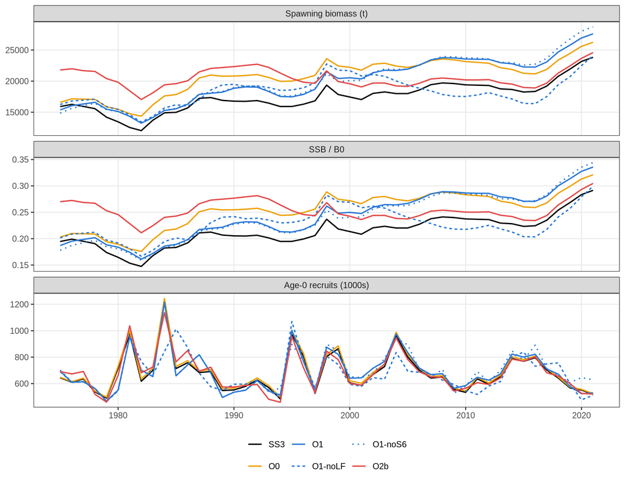

Figure 5: Spawning biomass, depletion and age-0 recruitment: SS3 B7 and the opal models (O2, not converged, is not shown; O2b has O2’s estimates).

```r
fit_models = c("SS3", "O0", "O1", "O1-noLF", "O1-noS6", "O2b")
tr = ALL[variant == variant_lab[["female"]] & model %in% fit_models]
tr[, model := factor(model, levels = fit_models)]
long = melt(tr, id.vars = c("model", "year"),
            measure.vars = c("ssb", "depletion", "recruits"))
long[, variable := factor(variable, labels = c("Spawning biomass (t)", "SSB / B0",
                                               "Age-0 recruits (1000s)"))]
ggplot(long, aes(year, value, colour = model, linetype = model, linewidth = model)) +
    geom_line() +
    facet_wrap(~variable, ncol = 1, scales = "free_y") +
    scale_models(fit_models) +
    labs(x = NULL, y = NULL, colour = NULL, linetype = NULL, linewidth = NULL)
```

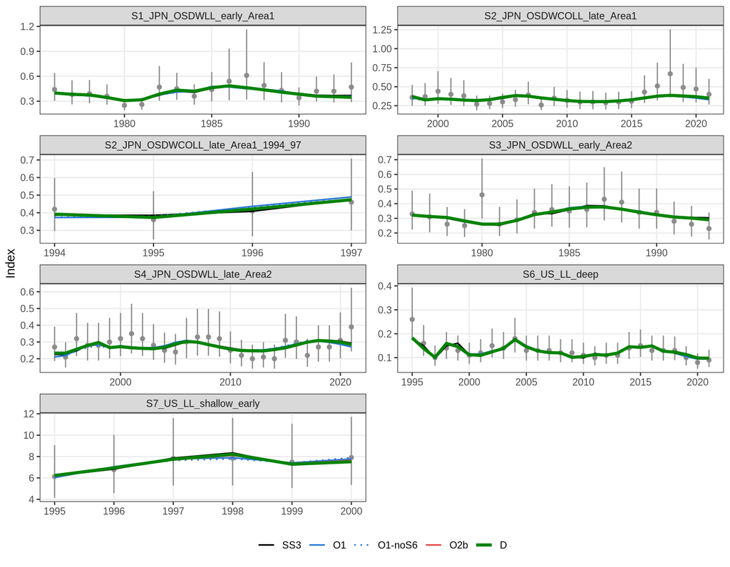

Figure 6: Fits to the indices (points: observed, with 95% intervals from the input SE). S6 is the recruitment index; O1-noS6 does not fit it (not shown for S6). D is the quarterly model (see Section 8).

```r
cp = copy(opal_c$cpue)
cp = merge(cp, opal_c$index_names, by = "index")
cp[, name := sub("_WCNPO", "", name)]
cp = cp[!(model == "O1-noS6" & grepl("^S6", name))]
cp[model == "SS3 B7", model := "SS3"]
cpue_models = c("SS3", "O1", "O1-noS6", "O2b", "D")
cp[, model := factor(model, levels = cpue_models)]
obs = unique(cp[model == "SS3", .(name, year, obs, se)])
ggplot() +
    geom_pointrange(data = obs, aes(year, obs, ymin = obs * exp(-1.96 * se),
                                    ymax = obs * exp(1.96 * se)), colour = "grey55", size = 0.2) +
    geom_line(data = cp, aes(year, pred, colour = model, linetype = model, linewidth = model)) +
    facet_wrap(~name, scales = "free", ncol = 2) +
    scale_models(cpue_models) +
    labs(x = NULL, y = "Index", colour = NULL, linetype = NULL, linewidth = NULL)
```

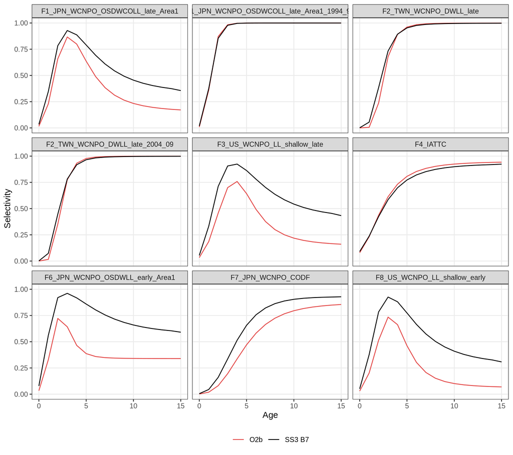

Figure 7: Selectivity-at-age in 2021: SS3 B7 (black) and opal O2b (red), for the fisheries with length compositions and the source fleets of the indices.

```r
sel = copy(opal_c$selectivity)
keep = c(1, 2, 3, 4, 6, 7, 8, 20, 22)
sel = sel[fishery %in% keep]
sel[, name := opal_c$fleets$name[fishery]]
ggplot(sel, aes(age, sel, colour = model)) +
    geom_line() +
    facet_wrap(~name, ncol = 3) +
    scale_colour_manual(values = c("SS3 B7" = "black", O2b = model_col[["O2b"]])) +
    labs(x = "Age", y = "Selectivity", colour = NULL)
```

# 7 The sex-averaged variant

B7s (Section 3) is converted with `config/npo-swo-b7s.yaml`, which differs from B7’s only in the SS3 model it reads. It is then taken through the same progression of opal models. The conversion is as exact as B7’s: the reconciliation passes, and SS3’s dynamics replayed with continuous catch and SS3’s catch weights reproduce SS3 B7s to 4.5e-06. opal’s growth curve, fitted to the sex-averaged mid-year lengths, has RMSE 0.51 cm, and its starting selectivity-at-age is within 0.015 of SS3’s.

```r
row = function(cache, sm, m) {
    x = cache$summary[model == m]
    data.table(B0 = fmt(x$B0, 0), Dep = fmt(x$depletion_2021, 3),
               Diff = if (grepl("^SS3", m)) "" else pct(max(abs(rel_ss3(cache, m)))),
               Conv = if (is.na(x$positive_hessian)) "" else ifelse(x$check_passes, "yes", "no"))
}
mods = c("SS3", "O0", "O1", "O2", "O2b", "O1-noLF", "O1-noS6")
tab = rbindlist(lapply(mods, function(m) {
    a = row(opal_c, "B7", if (m == "SS3") "SS3 B7" else m)
    b = row(opal_s, "B7s", if (m == "SS3") "SS3 B7s" else m)
    data.table(Model = if (m == "SS3") "SS3 (B7 / B7s)" else m,
               `B0, female` = a$B0, `Depl., female` = a$Dep, `Max. diff., female` = a$Diff,
               `B0, sex-avg.` = b$B0, `Depl., sex-avg.` = b$Dep, `Max. diff., sex-avg.` = b$Diff,
               `Converged (f / s)` = if (nzchar(a$Conv)) paste(a$Conv, b$Conv, sep = " / ") else "")
}))
tab[Model == "SS3 (B7 / B7s)", `Converged (f / s)` := ""]
knitr::kable(tab, format = "pipe", align = "lrrrrrrc")
```

Table 8: opal models for both variants: female biology (against SS3 B7) and sex-averaged biology (against SS3 B7s). Depletion is SSB2021/B0; ‘Max. diff.’ is the largest relative difference in spawning biomass from the variant’s SS3 model over 1975-2021.

| Model | B0, female | Depl., female | Max. diff., female | B0, sex-avg. | Depl., sex-avg. | Max. diff., sex-avg. | Converged (f / s) |
| --- | --- | --- | --- | --- | --- | --- | --- |
| SS3 (B7 / B7s) | 81,740 | 0.292 |  | 73,043 | 0.434 |  |  |
| O0 | 81,740 | 0.321 | 28% | 73,043 | 0.459 | 15% |  |
| O1 | 82,238 | 0.336 | 22% | 75,815 | 0.500 | 28% | yes / yes |
| O2 | 80,714 | 0.305 | 47% | 74,232 | 0.468 | 48% | no / no |
| O2b | 80,714 | 0.305 | 47% | 74,232 | 0.468 | 48% | yes / yes |
| O1-noLF | 80,572 | 0.299 | 24% | 64,053 | 0.367 | 38% | yes / yes |
| O1-noS6 | 83,504 | 0.344 | 24% | 76,901 | 0.510 | 29% | yes / yes |

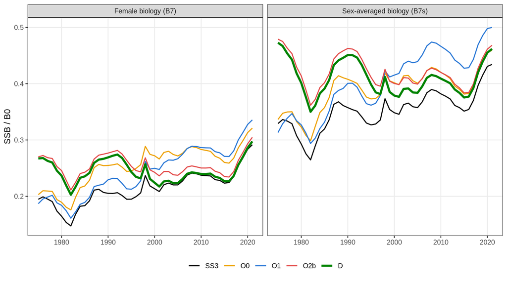

Figure 8: Depletion for both variants: SS3 B7 or B7s (black) against the opal models O0, O1, O2b and the final model, D.

```r
sx_models = c("SS3", "O0", "O1", "O2b", "D")
tr = ALL[model %in% sx_models]
tr[, model := factor(model, levels = sx_models)]
ggplot(tr, aes(year, depletion, colour = model, linetype = model, linewidth = model)) +
    geom_line() +
    facet_wrap(~variant) +
    scale_models(sx_models) +
    labs(x = NULL, y = "SSB / B0", colour = NULL, linetype = NULL, linewidth = NULL)
```

Sex-averaged biology makes the stock less depleted in both SS3 and opal, and opal’s models relate to SS3 B7s much as they relate to B7:

- **O0** is closer to SS3 (largest difference 15% against 28%). The sex-averaged initial F is smaller (0.229 against 0.326), so the initial equilibrium differs less.
- **O1** again estimates a less depleted stock than SS3 (0.500 against 0.434).
- **O2** again stops short with parameters on bounds (F3’s descending width and, here, F4’s inflection, which SS3 itself nearly puts on its bound). O2b, with 7 parameters fixed, converges at depletion 0.468.
- **Without the compositions (O1-noLF)**, the sex-averaged variant moves much further than the female one, to a smaller and more depleted stock than SS3’s: B<sub>0</sub> 64,053 t and depletion 0.367. Here the compositions, not only the indices, determine the stock’s scale.

# 8 Phase D: quarterly opal

opal can run several seasons per year. In each season it removes a share of M and that season’s catch at the season’s start (Pope). It predicts indices from that season’s numbers, and compositions from the year’s total catch-at-age. Phase D runs the annual opal models with four seasons and each fleet’s catch by quarter, taken from the quarterly SS3 model of the same chain (B3 or B3s, whose catch is B7’s before the quarters were summed). Everything else stays as in B7: spawning and recruitment at the start of the year, the indices in season 1, and the compositions by year. The quarterly shares of the catch are close to even (26%, 26%, 24%, 24% of the 1975-2021 total in quarters 1-4).

**Weight-at-age.** opal has one weight-at-age vector for the year. The annual models use SS3’s start-of-year weights, which suit a start-of-year removal. With catch in tonnes taken in later quarters, those weights convert each tonne into far too many fish. Age-0 fish weigh 0.03 kg at the start of the year and about 9 kg at mid-year. With start-of-year weights, the quarterly opal population at SS3’s values collapses after 2010. Table 9 replays SS3’s dynamics (SS3’s 1975 numbers and recruits, SS3’s selectivity) with each quarter’s catch removed at the start of the quarter. With start-of-year weights, spawning biomass ends 26% below SS3’s. With mid-year weights it stays within 9%. The phase D models therefore use SS3’s mid-year weight-at-age; the spawning output is unchanged.

```r
tt = merge(tq[, .(catch, weight, `Female, 2021` = pct(end, 1), `Female, max.` = pct(max, 1))],
           tq_s[, .(catch, weight, `Sex-avg., 2021` = pct(end, 1), `Sex-avg., max.` = pct(max, 1))],
           by = c("catch", "weight"), sort = FALSE)
knitr::kable(tt[, c(list(Catch = catch, `Catch weight` = weight), .SD), .SDcols = 3:6], format = "pipe")
```

Table 9: SS3’s dynamics replayed with each quarter’s catch removed at the start of the quarter: spawning biomass relative to SS3 (B7 or B7s) in 2021 and the largest absolute difference over 1975-2021. ‘Even’ splits each year’s catch equally over the quarters.

| Catch | Catch weight | Female, 2021 | Female, max. | Sex-avg., 2021 | Sex-avg., max. |
| --- | --- | --- | --- | --- | --- |
| by quarter | start of year | -26.4% | 30.1% | -10.7% | 12.1% |
| by quarter | mid-year | 1.9% | 8.6% | 1.2% | 5.7% |
| by quarter | SS3 fleet catch weight | 6.2% | 12.2% | 3.8% | 7.3% |
| even | start of year | -28.4% | 32.5% | -11.5% | 13.1% |
| even | mid-year | 0.6% | 3.7% | 0.5% | 3.0% |

Three models are run for each variant:

- **D0**: O0 with quarterly catch (SS3’s values, nothing estimated).
- **D0-even**: O0 with each year’s catch split evenly over the quarters.
- **D**: O2b, the final annual opal configuration (opal’s own selectivity, with the same parameters fixed), refitted with quarterly catch. With the catch taken through the year, M acts on fish before they are caught, so the same catch costs more fish. For the female variant, O2b’s estimates describe a stock too small for that, and the fit starts from them with ln(B<sub>0</sub>) raised by 0.2, the smallest step (of 0.1) at which the population stays positive. The sex-averaged fit starts at O2b’s estimates. In the sex-averaged D, one further selectivity parameter (F8’s descending width, close to its lower bound) dominates a flat direction of the Hessian and is fixed as in O2b.

```r
mods = c("O0", "D0", "D0-even", "O2b", "D")
tab = rbindlist(lapply(mods, function(m) {
    a = row(opal_c, "B7", m)
    b = row(opal_s, "B7s", m)
    data.table(Model = m, Seasons = ifelse(grepl("^D", m), 4, 1),
               `B0, female` = a$B0, `Depl., female` = a$Dep, `Max. diff., female` = a$Diff,
               `B0, sex-avg.` = b$B0, `Depl., sex-avg.` = b$Dep, `Max. diff., sex-avg.` = b$Diff,
               `Converged (f / s)` = if (grepl("0", m)) "" else paste(a$Conv, b$Conv, sep = " / "))
}))
tab = rbind(data.table(Model = "SS3 (B7 / B7s)", Seasons = 1,
                       `B0, female` = fmt(o("SS3 B7")$B0, 0), `Depl., female` = fmt(o("SS3 B7")$depletion_2021, 3),
                       `Max. diff., female` = "",
                       `B0, sex-avg.` = fmt(os("SS3 B7s")$B0, 0), `Depl., sex-avg.` = fmt(os("SS3 B7s")$depletion_2021, 3),
                       `Max. diff., sex-avg.` = "", `Converged (f / s)` = ""), tab)
knitr::kable(tab, format = "pipe", align = "lcrrrrrrc")
```

Table 10: Phase D against the annual opal models: depletion (SSB2021/B0) and the largest relative difference in spawning biomass from SS3 B7 (female) or B7s (sex-averaged). D is fitted; D0 and D0-even are at SS3’s values.

| Model | Seasons | B0, female | Depl., female | Max. diff., female | B0, sex-avg. | Depl., sex-avg. | Max. diff., sex-avg. | Converged (f / s) |
| --- | --- | --- | --- | --- | --- | --- | --- | --- |
| SS3 (B7 / B7s) | 1 | 81,740 | 0.292 |  | 73,043 | 0.434 |  |  |
| O0 | 1 | 81,740 | 0.321 | 28% | 73,043 | 0.459 | 15% |  |
| D0 | 4 | 81,740 | 0.305 | 13% | 73,043 | 0.442 | 7% |  |
| D0-even | 4 | 81,740 | 0.297 | 5% | 73,043 | 0.438 | 3% |  |
| O2b | 1 | 80,714 | 0.305 | 47% | 74,232 | 0.468 | 48% | yes / yes |
| D | 4 | 81,946 | 0.297 | 44% | 76,159 | 0.462 | 50% | yes / yes |

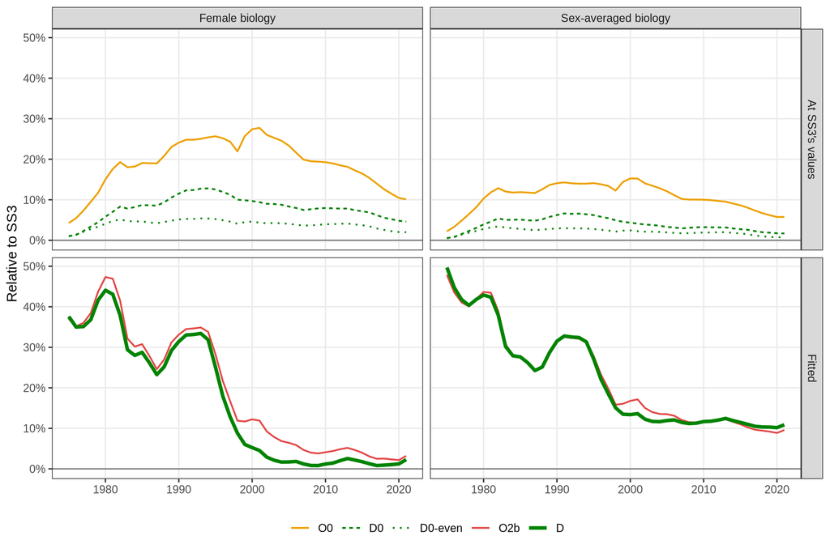

Figure 9: Spawning biomass relative to SS3 (B7 or B7s): annual opal (O0, O2b) against quarterly opal (D0, D0-even, D).

```r
rr = rbindlist(lapply(list(list(opal_c, "Female biology"), list(opal_s, "Sex-averaged biology")), function(a) {
    rbindlist(lapply(c("O0", "D0", "D0-even", "O2b", "D"), function(m)
        data.table(variant = a[[2]], model = m, year = 1975:2021, rel = rel_ss3(a[[1]], m))))
}))
rr[, kind := ifelse(model %in% c("O0", "D0", "D0-even"), "At SS3's values", "Fitted")]
rr[, model := factor(model, levels = c("O0", "D0", "D0-even", "O2b", "D"))]
ggplot(rr, aes(year, rel, colour = model, linetype = model, linewidth = model)) +
    geom_hline(yintercept = 0, colour = "grey50") +
    geom_line() +
    facet_grid(kind ~ variant) +
    scale_y_continuous(labels = scales::percent) +
    scale_models(c("O0", "D0", "D0-even", "O2b", "D")) +
    labs(x = NULL, y = "Relative to SS3", colour = NULL, linetype = NULL, linewidth = NULL)
```

At SS3’s values, quarterly opal is much closer to SS3 than annual opal. D0 stays within 13% (female) and 7% (sex-averaged) of SS3, against 28% and 15% for O0. With an even split (D0-even) the differences fall to 5% and 3%. SS3 B7 has one season, so its F is the same throughout the year, which an even split mimics more closely than the observed quarterly pattern. The initial equilibrium also moves closer to SS3’s (1975: 1.0% against 4.2%): opal spreads the initial F over the seasons.

Two caveats apply to these comparisons. First, SS3 B7 is an annual model whose catch is removed through the year at a constant F. The bridge has no quarterly SS3 model with B7’s timing: B3 is quarterly but still settles recruits in month 7, and settlement moves to month 1 (B6) only after the quarters are merged. The differences between D0 and SS3 therefore combine the effect of opal’s start-of-quarter removal with that of the observed quarterly catch pattern, which D0-even removes. Second, phase D uses mid-year weights in every quarter. This avoids the collapse, but it converts first-quarter catch in tonnes into too few fish and fourth-quarter catch into too many.

Fitted, D moves opal’s terminal state towards SS3’s. Depletion is 0.297 against O2b’s 0.305 (SS3 B7 0.292), and 0.462 against 0.468 for the sex-averaged variant (SS3 B7s 0.434). The objective also improves slightly (2,440.75 against 2,442.69). Like O2b, however, D starts the series well above SS3 (by 38% in 1975, against 37% for O2b). The difference in the early years therefore comes from opal’s own selectivity fit, which O2b and D share, not from catch timing.

# 9 From SS3 to the final opal model

Table 11 and Figure 10 trace the steps from the two-sex SS3 base case to D, the final opal model here (Section 9.1 sets out how it was chosen). Each row changes one thing from the row named in “from”, in SS3 (B1-B7) or through opal’s inputs (O0-D). opal is never changed. Every step is run for both biologies: female (left columns) and sex-averaged (right columns, B1s-B7s and the same opal models). Diagnostic branches (O1-noLF, O1-noS6, D0, D0-even) are described in Section 6 and Section 8.

```r
PG = data.table(
    Step   = c("B0", "B1 / B1s", "B7 / B7s", "O0", "O1", "O2", "O2b", "D"),
    From   = c("", "B0", "B1 / B1s", "B7 / B7s", "O0", "O1", "O2", "O2b"),
    Change = c("two-sex, quarterly SS3 base case (as supplied)",
               "one sex: female (B1) or sex-averaged (B1s) growth and M",
               "blocks as fleets; spawning, settlement and indices in month 1; one season",
               "opal at SS3's values with SS3's selectivity-at-age (nothing estimated)",
               "B0, recruitment and initial deviations, F6's initial F and q estimated",
               "opal's own selectivity curves, started at SS3's",
               "undetermined selectivity parameters fixed at O2's values",
               "four seasons with the observed quarterly catch; mid-year weights"),
    Status = c("converged", "converged", "converged", "not fitted", "converged",
               "not converged", "converged", "converged (final)"))
dep_ss3 = function(st) fmt(b(st)$depletion, 3)
PG[, `Depl. (f)` := c(dep_ss3("00-base"), dep_ss3("01-single-sex"), dep_ss3("07-index-month-1"),
                          sapply(c("O0", "O1", "O2", "O2b", "D"), function(m) fmt(o(m)$depletion_2021, 3)))]
PG[, `Diff. (f)` := c("", "", "",
                               sapply(c("O0", "O1", "O2", "O2b", "D"), function(m)
                                   pct(max(abs(rel_ss3_v("female", m))))))]
PG[, `Depl. (s)` := c(dep_ss3("00-base"), dep_ss3("01s-sex-averaged"), dep_ss3("07s-index-month-1"),
                            sapply(c("O0", "O1", "O2", "O2b", "D"), function(m) fmt(os(m)$depletion_2021, 3)))]
PG[, `Diff. (s)` := c("", "", "",
                                 sapply(c("O0", "O1", "O2", "O2b", "D"), function(m)
                                     pct(max(abs(rel_ss3_v("sexavg", m))))))]
pipe_table(PG, c(6, 6, 40, 11, 6, 6, 6, 6))
```

Table 11: Steps from the SS3 base case to the final opal model, D, with female (f) and sex-averaged (s) biology. Depl.: SSB2021/SSB0 (SS3) or SSB2021/B0 (opal). Diff.: the largest relative difference in spawning biomass over 1975-2021 from SS3 B7 (f) or B7s (s). Status: SS3 runs converged with positive-definite Hessians; opal fits as reported in Section 6.

| Step | From | Change | Status | Depl. (f) | Diff. (f) | Depl. (s) | Diff. (s) |
| --- | --- | --- | --- | --- | --- | --- | --- |
| B0 |  | two-sex, quarterly SS3 base case (as supplied) | converged | 0.358 |  | 0.358 |  |
| B1 / B1s | B0 | one sex: female (B1) or sex-averaged (B1s) growth and M | converged | 0.258 |  | 0.389 |  |
| B7 / B7s | B1 / B1s | blocks as fleets; spawning, settlement and indices in month 1; one season | converged | 0.292 |  | 0.434 |  |
| O0 | B7 / B7s | opal at SS3’s values with SS3’s selectivity-at-age (nothing estimated) | not fitted | 0.321 | 28% | 0.459 | 15% |
| O1 | O0 | B0, recruitment and initial deviations, F6’s initial F and q estimated | converged | 0.336 | 22% | 0.500 | 28% |
| O2 | O1 | opal’s own selectivity curves, started at SS3’s | not converged | 0.305 | 47% | 0.468 | 48% |
| O2b | O2 | undetermined selectivity parameters fixed at O2’s values | converged | 0.305 | 47% | 0.468 | 48% |
| D | O2b | four seasons with the observed quarterly catch; mid-year weights | converged (final) | 0.297 | 44% | 0.462 | 50% |

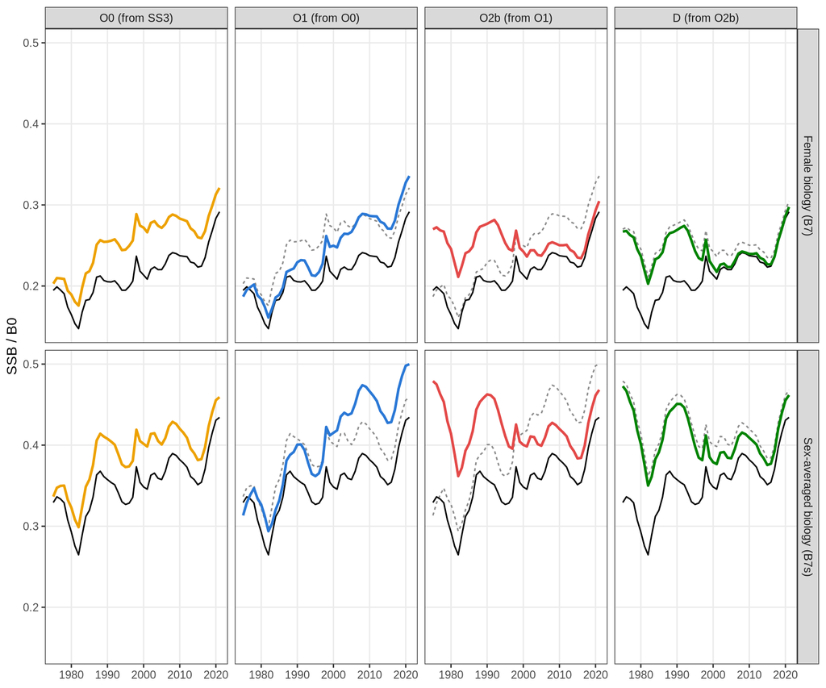

```r
steps = data.table(model = c("O0", "O1", "O2b", "D"), from = c("SS3", "O0", "O1", "O2b"))
steps[, panel := factor(paste0(model, " (from ", from, ")"), levels = paste0(model, " (from ", from, ")"))]
pg_dt = rbindlist(lapply(seq_len(nrow(steps)), function(i) rbind(
    ALL[model == steps$model[i], .(variant, panel = steps$panel[i], model, role = "step", year, depletion)],
    ALL[model == steps$from[i] & steps$from[i] != "SS3",
        .(variant, panel = steps$panel[i], model, role = "from", year, depletion)],
    ALL[model == "SS3", .(variant, panel = steps$panel[i], model, role = "SS3", year, depletion)])))
ggplot(mapping = aes(year, depletion)) +
    geom_line(data = pg_dt[role == "from"], colour = "grey55", linetype = "22", linewidth = 0.55) +
    geom_line(data = pg_dt[role == "SS3"], colour = "black", linewidth = 0.55) +
    geom_line(data = pg_dt[role == "step"], aes(colour = model), linewidth = 0.95) +
    scale_colour_manual(values = model_col, guide = "none") +
    facet_grid(variant ~ panel) +
    labs(x = NULL, y = "SSB / B0")
```

Read from left to right, the opal steps show where each difference from SS3 enters and leaves:

- **O0** (opal at SS3’s values) sits above SS3 throughout. Removing each year’s catch at the start of the year, and building the initial equilibrium the same way, leaves more spawners than SS3’s removal through the year (Section 5).
- **O1** (estimated, SS3’s selectivity) keeps that offset and ends less depleted than SS3 (0.336 against 0.292).
- **O2 and O2b** (opal’s own selectivity) change the shape of the series. The early years rise well above SS3’s (37% in 1975), while the terminal state moves back towards SS3’s (0.305). O2 itself stops short. O2b fixes the selectivity parameters that are on bounds or undetermined, and reaches the same estimates with a converged fit.
- **D** (quarterly catch) removes most of the catch-timing offset: at SS3’s values the quarterly model is within 13% of SS3, against 28% for O0 (Section 8). Fitted, D ends at depletion 0.297 against SS3 B7’s 0.292, the closest terminal state of the progression. The early-year difference from O2b remains, so it comes from opal’s selectivity fit, not from catch timing.

With sex-averaged biology the same pattern holds around a less depleted stock: D ends at 0.462 against SS3 B7s’s 0.434.

## 9.1 Choosing the final model, and its limitations

How close a model comes to SS3 was not a selection criterion, because matching SS3 is not the same as fitting the data. On that measure D is mixed (Table 12). With female biology it ends closest to SS3 in 2021. With sex-averaged biology O2b ends slightly closer in spawning biomass (D’s depletion is closer). Over the whole series, O1 stays closer than either.

```r
fin = rbindlist(lapply(c("female", "sexavg"), function(v) {
    Sv = if (v == "female") S else Ss
    rbindlist(lapply(c("O1", "O2b", "D"), function(m) {
        x = Sv[model == m]
        xd = Sv[model == "D"]
        r = rel_ss3_v(v, m)
        data.table(Variant = c(female = "female", sexavg = "sex-averaged")[[v]], Model = m,
                   Selectivity = if (m == "O1") "SS3, fixed" else "opal, estimated",
                   Seasons = if (m == "D") 4L else 1L,
                   Conv. = if (isTRUE(x$check_passes)) "yes" else "no",
                   Obj. = fmt(x$objective, 2), k = x$n_par,
                   dAIC = fmt(2 * (x$objective - xd$objective) + 2 * (x$n_par - xd$n_par), 1),
                   `Depl. 2021` = fmt(x$depletion_2021, 3),
                   `Diff. 2021` = pct(last(r)), `Mean diff.` = pct(mean(abs(r))),
                   `Max. diff.` = pct(max(abs(r))))
    }))
}))
pipe_table(fin, c(8, 5, 12, 4, 4, 8, 3, 5, 6, 6, 6, 6))
```

Table 12: Candidates for the final model, by variant. Obj.: opal’s objective (negative log-likelihood) (same data and likelihood in every row); Conv.: converged; k: estimated parameters; dAIC: 2 x (objective difference) + 2 x (k difference), relative to D. Diff. 2021: relative difference in spawning biomass from SS3 B7 (female) or B7s (sex-averaged) in 2021; Mean and Max. diff.: mean and largest absolute relative difference over 1975-2021.

| Variant | Model | Selectivity | Seasons | Conv. | Obj. | k | dAIC | Depl. 2021 | Diff. 2021 | Mean diff. | Max. diff. |
| --- | --- | --- | --- | --- | --- | --- | --- | --- | --- | --- | --- |
| female | O1 | SS3, fixed | 1 | yes | 2,493.04 | 66 | 68.6 | 0.336 | 16% | 14% | 22% |
| female | O2b | opal, estimated | 1 | yes | 2,442.69 | 84 | 3.9 | 0.305 | 3% | 19% | 47% |
| female | D | opal, estimated | 4 | yes | 2,440.75 | 84 | 0.0 | 0.297 | 2% | 17% | 44% |
| sex-averaged | O1 | SS3, fixed | 1 | yes | 2,495.66 | 66 | 68.4 | 0.500 | 19% | 18% | 28% |
| sex-averaged | O2b | opal, estimated | 1 | yes | 2,445.37 | 85 | 5.8 | 0.468 | 10% | 23% | 48% |
| sex-averaged | D | opal, estimated | 4 | yes | 2,443.45 | 84 | 0.0 | 0.462 | 11% | 22% | 50% |

Caveats and limitations of D:

- **It does not track SS3 most closely.** Over 1975-2021, O1 stays closer to SS3: its mean difference is 14% against D’s 17%, and its largest 22% against D’s 44%. D comes closest only at the end of the series, and only with female biology. Its early years are 38% above SS3’s in 1975, a difference that comes from opal’s selectivity fit (O2b shows the same), not from catch timing.
- **The objective comparison is only partly fair.** D against O2b is like-for-like (same estimated parameters, same data), but D’s advantage is small (1.9 objective units, female). O1’s parameter count leaves out its selectivity, which SS3 estimated from the same data, so its AIC penalty is understated and the comparison with O1 is indicative only.
- **Selectivity parameters are fixed at values chosen from the fit.** 8 (female) and 8 (sex-averaged) selectivity parameters are fixed because they are on a bound or the likelihood is flat along them (Table 7). The fixed sets differ between the variants, so the two D models are not quite the same model. The standard errors treat the fixed values as known, so D’s uncertainty is understated.
- **D rests on approximations of the quarterly structure.**
  - Mid-year weight-at-age is used in every quarter (opal has one weight vector), which converts first-quarter catch into too few fish and fourth-quarter catch into too many.
  - Compositions are predicted from the year’s catch with one length-at-age.
  - Spawning and recruitment are at the start of the year, not in months 5 and 7 as in the base case.
- **Its reference is an annual SS3 model.** SS3 B7 removes catch at a constant F through the year, and the bridge has no quarterly SS3 model with B7’s timing. The comparison of D with SS3 therefore mixes catch timing with the quarterly catch pattern.
- **Its starting point was adjusted, and it was fitted from one start.** The female D starts from O2b’s estimates with ln(B<sub>0</sub>) raised by 0.2, so that the population stays positive. Unlike the SS3 annual steps, D was not checked from several starting points.
- **The biology matters more than the opal configuration.** Terminal depletion differs more between the female and sex-averaged variants (0.297 against 0.462) than between any two converged opal models of one variant. Neither single-sex biology is the base case’s two-sex model.
- **These are preliminary explorations,** not advice on the stock.

# 10 Limitations and differences from SS3

## 10.1 Not available in opal

- **Two sexes.** opal tracks one population vector and scales spawning potential by a sex ratio. Modelling the base case needs a sex dimension in the numbers-at-age, sex-specific growth and M, and spawning biomass from females only. The compositions here are sex-combined, so sex-specific composition likelihoods are not needed. The predicted combined composition would sum the two sexes’ catches. B1 against B1s and B0 shows that the choice of single-sex biology moves terminal depletion between 0.258 (female) and 0.389 (sex-averaged), against 0.358 with two sexes.
- **Seasons with annual ages.** opal has `n_season`, and within a season its catch and index predictions are seasonal. However:
  - it predicts compositions from the year’s total catch-at-age with one length-at-age for the whole year, not by season;
  - it has one weight-at-age vector for the year;
  - it spawns and recruits only at the start of season 1, whereas the base case spawns in month 5 and recruits settle in month 7.

  The SS3-to-opal converter handles one season per year only. Phase D (see Section 8) expands B7’s annual inputs to four quarters in the case-study script. Seasonal opal models would also need season-specific weight-at-age (with one start-of-year weight vector, quarterly removals of catch in tonnes collapse the stock) and season-specific length-at-age to predict quarterly compositions.
- **Spawning and settlement timing.** opal’s spawning biomass is that at the start of the year, before any mortality. B3 shows that moving spawning from month 5 to month 1 raises SSB<sub>0</sub> by 6% and terminal depletion from 0.259 to 0.279. A spawning-time fraction (M and F applied before spawning) would remove this step.
- **Time-varying selectivity.** Blocks cannot be estimated. Blocks that replace parameters are reproduced exactly by splitting the fleet (B2), but every fleet that mirrors a blocked fleet has to be split too (here seven fleets). A split index needs its own catchability or a shared one, and SS3’s shared q (link 2) does not converge.
- **Recruitment index.** opal has no index of the year’s recruitment (SS3 units 33). An index in numbers with age-0 selectivity reproduces it at the start of the year. Because `sel_fa_external` replaces every fishery’s selectivity, a fit with opal’s own curves needs an age-based curve pinned to that shape. A per-fishery external selectivity, or an index type for recruitment (or for any age range), would avoid the workaround.
- **Analytical (floated) catchability.** SS3 solves q; opal estimates it.

## 10.2 Structural differences handled in the conversion

- **Catch timing.** opal removes each season’s catch at its start; SS3’s hybrid F removes it through the season. At SS3’s values this leaves spawning biomass up to 18% above SS3’s (Table 5). A mid-season (Pope) removal would be within 5%. Quarterly opal seasons (see Section 8) come within 13%, given mid-year weights.
- **Initial equilibrium.** opal’s initial equilibrium removes the initial-F catch at the start of the year. Its 1975 spawning biomass at SS3’s values is 4.2% above SS3’s. A Baranov or mid-year removal in `get_initial_numbers()` would match SS3.
- **Catch weight.** opal converts catch in weight to numbers with one weight-at-age (start of year in the annual models, mid-year in phase D). SS3 uses each fleet’s catch weight-at-age (selectivity-weighted, mid-season).
- **Length-at-age for selectivity and compositions.** SS3 forms a fishery’s selectivity-at-age and expected compositions from mid-year lengths. opal uses one length-at-age, here fitted to SS3’s mid-year lengths. The biology stays at the start of the year.
- **Growth below the first reference age.** SS3 grows age-0 fish linearly from settlement to L1 at age 0.5. opal’s Schnute curve cannot represent this, which matters only at the start of the year.
- **Fleet layout.** SS3 3.30 allows fishing fleets after the surveys (here the block fleets 28-34). The converter maps SS3 fleets to opal fisheries by fleet type.

## 10.3 What the bridge itself changes

The single-sex step is not neutral. B1 applies female M and growth to every fish. Males live longer and grow larger than they do in the base case, and the stock is smaller and more depleted. B1s, with sex-averaged biology, is closer to the base case, but merging its quarters costs more fit (B4s). Either choice is an approximation that opal’s lack of sexes forces. With the sex-combined compositions here, a two-sex opal would need no new data. The timing steps (B3, B6) move spawning and settlement to the start of the year. B3 is required for SS3 itself to merge the seasons, and both change the stock’s scale and productivity (SSB<sub>MSY</sub>, F<sub>MSY</sub>). These are differences between the base case and opal’s structure, not between SS3 and opal.

# Reproducing this document

| Step | Script | Writes |
| --- | --- | --- |
| 1 | `scripts/01-build-ss3-bridge.r` | the SS3 bridge models and `vignettes/data/npo-swo-ss3-bridge-cache.rds` |
| 2 | `scripts/02-convert-fit-npo-swo-opal.r` | `vignettes/data/npo-swo-opal-cache.rds` and the fitted models (female biology) |
| 3 | `NPO_SWO_VARIANT=sexavg scripts/02-convert-fit-npo-swo-opal.r` | `vignettes/data/npo-swo-opal-cache-sexavg.rds` and the fitted models (sex-averaged biology) |
| 4 | `quarto render vignettes/npo-swo-ss3-to-opal.qmd` | this document |

```r
cat(sprintf("Caches: bridge %s (SS3 %s); opal %s and %s (opal %s, r4ss %s, R %s).\n",
            bridge$made_at, bridge$ss3_version, opal_c$created, opal_s$created,
            opal_c$session$opal, opal_c$session$r4ss, opal_c$session$r))
```

```
Caches: bridge 2026-11-13 18:13:36 UTC (SS3 3.30.22.1); opal 2026-11-13 18:28:21 UTC and 2026-11-13 18:26:49 UTC (opal 0.1.3, r4ss 1.56.0, R 4.5.3).
```

# References

ISC Billfish Working Group. 2023. *Stock Assessment Report for Swordfish (Xiphias gladius) in the North Pacific Through 2021*. Report of the 23rd Meeting of the ISC, Annex 11 ISC/23/ANNEX/11. International Scientific Committee for Tuna; Tuna-Like Species in the North Pacific Ocean.

Methot, Richard D., and Chantell R. Wetzel. 2013. “Stock Synthesis: A Biological and Statistical Framework for Fish Stock Assessment and Fishery Management.” *Fisheries Research* 142: 86–99. https://doi.org/10.1016/j.fishres.2012.10.012.